# Textanalyse mit `quanteda`: Wiederholungen und Vorgriff

Philipp Meyer, Institut für Politikwissenschaft

05.05.2021, Tokens und DFM, Seminar: Quantitative Textanalyse

# 1. Einleitung

Dieses Tutorial ist zum großen Teil eine Wiederholung und zu einem kleinen Teil ein Vorgriff auf noch kommende Tutorials.

In den folgenden Abschnitten werden wir alle nötigen Schritte einer Textanalyse durchgehen. Dafür verwenden wir natürlich das `quanteda`-Paket. Das Ziel dieses Tutorials ist es euch ein sicheres Verständnis zu vermitteln, welche Schritte bei einer Textanalyse tatsächlich gemacht werden müssen. Außerdem dienen die gewollten Wiederholen dazu, dass ihr sicherer und geübter im Umgang mit `quanteda` und der Textanalyse werdet.

# 2. `quanteda`

Das [quanteda-Paket](https://quanteda.io/) ist ein Textanalyse-Paket für `R`. Es deckt nahezu alles ab, was nötig ist, um eine Textanalyse durchzuführen. Natürlich bietet `quanteda` auch eine klare und umfangreiche Dokumentation und eine Vielzahl an Tutorials.

Wir werden uns in diesem Tutorial auf die wichtigsten Schritte zur Vorbereitung einer Textanalyse konzentrieren und lernen, wie man die [quanteda-Dokumentation](https://quanteda.io/reference/index.html) für die einzelnen Funktionen nutzt.

Der Pflichttext für diese Sitzung von [Welbers, van Atteveldt und Benoit, 2017](https://www.tandfonline.com/doi/abs/10.1080/19312458.2017.1387238) bespricht ebenfalls alle Schritte, welche wir jetzt besprechen werden.

Zur Erinnerung: das `quanteda`-Paket und seine Nebenpakete müsst ihr beide jeder `R`-Sitzung laden, jedoch nur einmal vorher installieren:

```r
#install.packages("quanteda.textplots")
#install.packages("quanteda.textstats")
# install.packages("quanteda") # Falls noch nicht geschehen, dann bitte installiert das Paket bitte.

library(quanteda)
library(quanteda.textplots)
library(quanteda.textstats)
```

# 3. Textanalyse mit `quanteda`

Im folgenden werden wir die klassischen Schritte einer Textanalyse durchsprechen:

1. Texte importieren und Korpus erstellen
2. Dokumentenmatrix erstellen, bereinigen und filtern (Der wichtigste Teilschritt! Hier entscheidt sich die Güte der nachfolgenden Analyse)
3. Analyse (Dieser Schritt wird nur kurz besprochen, da wir im Verlauf des Seminars einzelne Analysemethoden im Detail besprechen werden.)

### 3.1 Schritt 1: Texte importieren und Korpus erstellen

Der erste Schritt einer Textanalyse ist immer die zu analysierenden Texte in `R` einzulesen. Textdateien werden in einer Vielzahl von Formaten gespeichert: einfache txt-Files, csv-Dateien, html-Dateien und natürlich PDF. Erfahrungsgemäß machen einfache txt-Dateien die wenigsten Probleme. Eine Anleitung wie ihr txt-Dateien einlest findet ihr im zweiten Tutorial zu dieser Sitzung (Titel: "Erste Schritte mit `quanteda`"). Das Einlesen von Textdaten mit `quanteda` funktioniert am effizientesten mit dem `readtext`-Paket und dem `readr`-Paket.

```r
# install.packages("readtext") # Falls noch nicht geschehen, dann bitte installiert das Paket bitte.
# install.packages("readr")
# install.packages("tidyverse")

library(readtext)
library(readr)
library(tidyverse)
```

#### 3.1.1 Texte aus CSV Dateien importieren

Der Einfachheit halber verwenden wir eine csv-Datei, die online verfügbar ist. Der Prozess des Einlesens der Daten ist identisch zu dem des Einlesens einer csv-Datei die ihr auf eurem Computer gespeichert habt (hier müsst ihr dann euren Computerpfad verwenden).

Die Datei die wir jetzt importieren beinhaltet die State of the Union-Reden der US-Präsidenten, wobei jedes Dokument (d.h. jede Zeile in der csv-Datei) ein Absatz einer Rede ist. Die Daten werden als ein data.frame importiert.

```r
sotu_url <-  "https://bit.ly/2QoqUQS"
sotu_data <-  read_csv(sotu_url)
head(sotu_data)   ## view first 6 rows
```

```
## # A tibble: 6 x 5
##   paragraph date       President     Party text
##       <dbl> <date>     <chr>         <chr> <chr>
## 1         1 1790-01-08 George Washi… Other I embrace with great satisfaction th…
## 2         2 1790-01-08 George Washi… Other In resuming your consultations for t…
## 3         3 1790-01-08 George Washi… Other Among the many interesting objects w…
## 4         4 1790-01-08 George Washi… Other A free people ought not only to be a…
## 5         5 1790-01-08 George Washi… Other The proper establishment of the troo…
## 6         6 1790-01-08 George Washi… Other There was reason to hope that the pa…
```

Jetzt können wir einen `quanteda`-Corpus mit der `corpus`-Funktion erstellen. Wie immer gilt: wenn ihr mehr über die Funktion und ihre Möglichkeiten erfahren wollt, dann nutzt die help-Page --> `?corpus`.

Für unser Beispiel müssen wir `quanteda` informieren, dass wir einen data.frame verwenden und welche Spalte des Datensatzes das Textfeld enthält:

```r
sotu_corpus <-  corpus(sotu_data, text_field = "text")
sotu_corpus
```

```
## Corpus consisting of 23,469 documents and 4 docvars.
## text1 :
## "I embrace with great satisfaction the opportunity which now ..."
##
## text2 :
## "In resuming your consultations for the general good you can ..."
##
## text3 :
## "Among the many interesting objects which will engage your at..."
##
## text4 :
## "A free people ought not only to be armed, but disciplined; t..."
##
## text5 :
## "The proper establishment of the troops which may be deemed i..."
##
## text6 :
## "There was reason to hope that the pacific measures adopted w..."
##
## [ reached max_ndoc ... 23,463 more documents ]
```

#### 3.1.2 Texte aus Word und PDF-Dateien importieren

Anstelle einer csv-Datei ist es natürlich auch möglich weitere Dateiformate zu importieren. Zum Beispiel txt-, .pdf- oder .docx-Dateien.

```r
url <-  "https://github.com/phimeyer/phimeyer.github.io/raw/master/_teaching/files.zip"
texts <-  readtext(url)
texts
```

```
## readtext object consisting of 2 documents and 0 docvars.
## # Description: df[,2] [2 × 2]
##   doc_id        text
##   <chr>         <chr>
## 1 document.docx "\"This is a \"..."
## 2 pdf_file.pdf  "\"This is a \"..."
```

Wie ihr steht, wurden die Dateien automatisch heruntergeladen, entpackt und in einfachen Text umgewandelt.

Wir können Texte natürlich auch von unserer lokalen Festplatte lesen (das ist in den meisten Fällen auch der "normale" Weg, da wir ja zu erst die Dokumente herunterladen). Hierfür müssen wir lediglich den Pfad angeben:

```r
texts <-  readtext("c:/pfad/zu/unseren/dateien")
texts <-  readtext("/Benutzer/ich/Dokumente/dateien")
```

### 3.2 Schritt 2: Erstellen einer DTM (oder DFM)

Die meisten Textanalysen basieren auf den Häufigkeiten von Wörtern in Dokumenten. Das wird als **Bag-of-Words**-Annahme bezeichnet: die Texte sind die Säcke in denen einzelne Wörter stecken. Interpunktion, Wortreihenfolge, Füllwörter und einzelne häufig vorkommende Wörter werden in diesem Vorgehen bereits in den ersten Schritten gelöscht. Obwohl dadurch viele relevante Informationen ignoriert werden, hat sich dieser Ansatz als leistungsfähig und effizient erwiesen.

Das Standardformat für die Darstellung eines Bag-of-Words ist eine Dokument-Term-Matrix (DTM). Hierbei handelt es sich um eine Matrix, in der Zeilen Dokumente sind und die Spalten Wörter repräsentieren. Wir werden zunächst eine kleine Beispiel-DTM aus ein paar Zeilen Text erstellen. Hier verwenden wir die `tokens`-Funktion und die `dfm`-Funktion von `quanteda`. dfm steht für *Document-Feature-Matrix*:

```r
text <-  c(d1 = "Die Leibniz Universität Hannover macht gute Lehre.",
           d2 = "Mit mehr Katzen wäre die Lehre noch besser!",
           d3 = "Warum denn eine Katze? Ein Hund ist viel zutraulicher.",
           d4 = "Wir wollen viele Katzen!")

text_tokens <- tokens(text)
dtm <- dfm(text_tokens)
dtm
```

```
## Document-feature matrix of: 4 documents, 28 features (70.54% sparse) and 0 docvars.
##     features
## docs die leibniz universität hannover macht gute lehre . mit mehr
##   d1   1       1           1        1     1    1     1 1   0    0
##   d2   1       0           0        0     0    0     1 0   1    1
##   d3   0       0           0        0     0    0     0 1   0    0
##   d4   0       0           0        0     0    0     0 0   0    0
## [ reached max_nfeat ... 18 more features ]
```

Mit diesem Matrixformat können wir jetzt Analysen durchführen, wie z. B. die Analyse verschiedener Frames in Bezug auf Katzen, oder die Berechnung der Ähnlichkeit zwischen dem dritten Satz und den ersten beiden Sätzen.

#### 3.2.1 Das sogenannte pre-processing: die DFM aufarbeiten und bereinigen

Die direkte Umwandlung eines Textes in einen DFM ist sehr vereinfachend. Beachtet z. B., dass die Wörter "Katzen" und "Katze" unterschiedliche Spalten erhalten. Außerdem sind "Hannover" und "Lehre" genauso unterschiedlich wie "Katzen" und "Katze". Das ist ein Problem, vor allem da wir eher an der Tatsache interessiert sind, dass es in den Sätzen um Katzen geht und weniger um das spezifische Wort an sich. Wir wollen also den Inhalt analysieren. Weiterhin sind Textanalysen vor allem dann aussagekräftig, wenn weniger interessante Wörter wie "die" oder selte Wörter wie "Universität" ignoriert werden.

Um das zu erreichen, müssen wir zusätzliche Verarbeitungsschritte einfügen. Im nächsten Bespiel erstellen wir eine DFM. Vorher konvertieren wir die Texte in tokens und transformieren dabei alle Buchstaben zu Kleinbuchstaben, ignorieren Füllwörter (`tokens_remove(pattern = stopwords("de"))`) und die Interpunktion.

Zusätzlich erstellen wir eine zweite DFM mit unseren State-of-the-Union-Reden (siehe oben) und führen dort zusätzlich ein Stemming durch (stemming fünktioniert mit der deutschen Sprache weniger gut, weshalb unsere Beispielsätze hierfür nicht geeignet sind). Einfach ausgedrückt, werden beim Stemming Wörter auf ihren Wortstamm reduziert. Dadurch werden einige Teile an den Wortenden entfernt und so verschiedene Formen desselben Wortes ignoriert. Zum Beispiel Singular versus Plural ("gun" oder "gun-s") und verschiedene Verbformen ("walk", "walk-ing", "walk-s").

```r
# Beispiel 1: Unsere drei Sätze
text_tokens <- tokens(text, remove_punct=T) %>%
  tokens_remove(pattern = stopwords("de")) %>%
  tokens_tolower()
sätze_dtm <-  dfm(text_tokens)
sätze_dtm
```

```
## Document-feature matrix of: 4 documents, 15 features (71.67% sparse) and 0 docvars.
##     features
## docs leibniz universität hannover macht gute lehre mehr katzen wäre besser
##   d1       1           1        1     1    1     1    0      0    0      0
##   d2       0           0        0     0    0     1    1      1    1      1
##   d3       0           0        0     0    0     0    0      0    0      0
##   d4       0           0        0     0    0     0    0      1    0      0
## [ reached max_nfeat ... 5 more features ]
```

```r
# Beispiel 2: SOTU
sotu_tokens <- tokens(sotu_corpus, remove_punct=T) %>%
  tokens_remove(pattern = stopwords("en")) %>%
  tokens_tolower() %>%
  tokens_wordstem()
sotu_dfm <-  dfm(sotu_tokens)
sotu_dfm
```

```
## Document-feature matrix of: 23,469 documents, 20,201 features (99.82% sparse) and 4 docvars.
##        features
## docs    embrac great satisfact opportun now present congratul favor prospect
##   text1      1     1         1        1   1       2         1     1        1
##   text2      0     0         0        0   0       1         0     0        0
##   text3      0     0         0        0   0       0         0     0        0
##   text4      0     0         0        0   0       0         0     0        0
##   text5      0     0         0        0   0       0         0     0        0
##   text6      0     0         0        0   0       0         0     0        0
##        features
## docs    public
##   text1      1
##   text2      0
##   text3      0
##   text4      0
##   text5      0
##   text6      0
## [ reached max_ndoc ... 23,463 more documents, reached max_nfeat ... 20,191 more features ]
```

```r
# Beispiel 2: SOTU, ANDERE SCHREIBWEISE
sotu_dfm <- sotu_corpus %>%
  tokens(remove_punct=T) %>%
  tokens_remove(pattern = stopwords("en")) %>%
  tokens_tolower() %>%
  tokens_wordstem() %>%
  dfm()
sotu_dfm
```

```
## Document-feature matrix of: 23,469 documents, 20,201 features (99.82% sparse) and 4 docvars.
##        features
## docs    embrac great satisfact opportun now present congratul favor prospect
##   text1      1     1         1        1   1       2         1     1        1
##   text2      0     0         0        0   0       1         0     0        0
##   text3      0     0         0        0   0       0         0     0        0
##   text4      0     0         0        0   0       0         0     0        0
##   text5      0     0         0        0   0       0         0     0        0
##   text6      0     0         0        0   0       0         0     0        0
##        features
## docs    public
##   text1      1
##   text2      0
##   text3      0
##   text4      0
##   text5      0
##   text6      0
## [ reached max_ndoc ... 23,463 more documents, reached max_nfeat ... 20,191 more features ]
```

```r
# Beispiel 2: SOTU, SCHREIBWEISE OHNE PIPELINE-OPERATOR
sotu_tokens <- tokens(sotu_corpus, remove_punct=T)
sotu_tokens <-  tokens_remove(sotu_tokens, pattern = stopwords("en"))
sotu_tokens <-  tokens_tolower(sotu_tokens)
sotu_tokens <-  tokens_wordstem(sotu_tokens)
sotu_dfm <-  dfm(sotu_tokens)

sotu_dfm
```

```
## Document-feature matrix of: 23,469 documents, 20,201 features (99.82% sparse) and 4 docvars.
##        features
## docs    embrac great satisfact opportun now present congratul favor prospect
##   text1      1     1         1        1   1       2         1     1        1
##   text2      0     0         0        0   0       1         0     0        0
##   text3      0     0         0        0   0       0         0     0        0
##   text4      0     0         0        0   0       0         0     0        0
##   text5      0     0         0        0   0       0         0     0        0
##   text6      0     0         0        0   0       0         0     0        0
##        features
## docs    public
##   text1      1
##   text2      0
##   text3      0
##   text4      0
##   text5      0
##   text6      0
## [ reached max_ndoc ... 23,463 more documents, reached max_nfeat ... 20,191 more features ]
```

Das `tokens_tolower`-Argument bestimmt, ob Texte in Kleinbuchstaben umgewandelt werden oder nicht. `tokens_wordstem` bestimmt, ob Stemming verwendet wird oder nicht.

Ihr müsst die Befehle übrigens nicht als Pipeline (`%>%`) schreiben. Alternativ könnt ihr die Funktionen auch einzeln ausführen (und dabei das jeweilige Objekt immer wieder einzeln ansteuern):

```r
sotu_tokens <- tokens(sotu_corpus, remove_punct=T)
sotu_tokens <-  tokens_remove(sotu_tokens, pattern = stopwords("en"))
sotu_tokens <-  tokens_tolower(sotu_tokens)
sotu_tokens <-  tokens_wordstem(sotu_tokens)
sotu_dfm <-  dfm(sotu_tokens)
sotu_dfm
```

```
## Document-feature matrix of: 23,469 documents, 20,201 features (99.82% sparse) and 4 docvars.
##        features
## docs    embrac great satisfact opportun now present congratul favor prospect
##   text1      1     1         1        1   1       2         1     1        1
##   text2      0     0         0        0   0       1         0     0        0
##   text3      0     0         0        0   0       0         0     0        0
##   text4      0     0         0        0   0       0         0     0        0
##   text5      0     0         0        0   0       0         0     0        0
##   text6      0     0         0        0   0       0         0     0        0
##        features
## docs    public
##   text1      1
##   text2      0
##   text3      0
##   text4      0
##   text5      0
##   text6      0
## [ reached max_ndoc ... 23,463 more documents, reached max_nfeat ... 20,191 more features ]
```

Die `tokens_remove`-Funktion ist etwas kniffliger. Wenn ihr einen Blick in die Dokumentation der Funktionen (`?`) werft, werdet ihr sehen, dass `remove` verwendet werden kann, um bestimmte benutzerinnendefinierte Merkmale bzw. Muster zu ignorieren. In diesem Fall haben wir tatsächlich eine andere Funktion, `stopwords()`, verwendet, um eine Liste von Füllwörtern zu entfernen.

```r
stopwords('de')
```

```
##   [1] "aber"      "alle"      "allem"     "allen"     "aller"     "alles"
##   [7] "als"       "also"      "am"        "an"        "ander"     "andere"
##  [13] "anderem"   "anderen"   "anderer"   "anderes"   "anderm"    "andern"
##  [19] "anderr"    "anders"    "auch"      "auf"       "aus"       "bei"
##  [25] "bin"       "bis"       "bist"      "da"        "damit"     "dann"
##  [31] "der"       "den"       "des"       "dem"       "die"       "das"
##  [37] "daß"       "derselbe"  "derselben" "denselben" "desselben" "demselben"
##  [43] "dieselbe"  "dieselben" "dasselbe"  "dazu"      "dein"      "deine"
##  [49] "deinem"    "deinen"    "deiner"    "deines"    "denn"      "derer"
##  [55] "dessen"    "dich"      "dir"       "du"        "dies"      "diese"
##  [61] "diesem"    "diesen"    "dieser"    "dieses"    "doch"      "dort"
##  [67] "durch"     "ein"       "eine"      "einem"     "einen"     "einer"
##  [73] "eines"     "einig"     "einige"    "einigem"   "einigen"   "einiger"
##  [79] "einiges"   "einmal"    "er"        "ihn"       "ihm"       "es"
##  [85] "etwas"     "euer"      "eure"      "eurem"     "euren"     "eurer"
```

[output cut: 24 more lines]

```r
stopwords('en')
```

```
##   [1] "i"          "me"         "my"         "myself"     "we"
##   [6] "our"        "ours"       "ourselves"  "you"        "your"
##  [11] "yours"      "yourself"   "yourselves" "he"         "him"
##  [16] "his"        "himself"    "she"        "her"        "hers"
##  [21] "herself"    "it"         "its"        "itself"     "they"
##  [26] "them"       "their"      "theirs"     "themselves" "what"
##  [31] "which"      "who"        "whom"       "this"       "that"
##  [36] "these"      "those"      "am"         "is"         "are"
##  [41] "was"        "were"       "be"         "been"       "being"
##  [46] "have"       "has"        "had"        "having"     "do"
##  [51] "does"       "did"        "doing"      "would"      "should"
##  [56] "could"      "ought"      "i'm"        "you're"     "he's"
##  [61] "she's"      "it's"       "we're"      "they're"    "i've"
##  [66] "you've"     "we've"      "they've"    "i'd"        "you'd"
##  [71] "he'd"       "she'd"      "we'd"       "they'd"     "i'll"
```

[output cut: 20 more lines]

Es gibt weitere Techniken zum pre-processing. Für weitere Details lest den Text von [Welbers, van Atteveldt und Benoit, 2017](https://www.tandfonline.com/doi/abs/10.1080/19312458.2017.1387238).

#### 3.2.2 Eine DFM filtern

Wir können die Funktion `dfm_trim` verwenden, um bestimmte Wörter zu entfernen. Im Beispiel definieren wir, dass wir alle Wörter entfernen wollen die weniger als 10 Mal vorkommen (d. h. der Summenwert der Spalte im DFM).

```r
dtm  <-  dfm_trim(sotu_dfm, min_termfreq = 10)
dtm
```

```
## Document-feature matrix of: 23,469 documents, 5,299 features (99.36% sparse) and 4 docvars.
##        features
## docs    embrac great satisfact opportun now present congratul favor prospect
##   text1      1     1         1        1   1       2         1     1        1
##   text2      0     0         0        0   0       1         0     0        0
##   text3      0     0         0        0   0       0         0     0        0
##   text4      0     0         0        0   0       0         0     0        0
##   text5      0     0         0        0   0       0         0     0        0
##   text6      0     0         0        0   0       0         0     0        0
##        features
## docs    public
##   text1      1
##   text2      0
##   text3      0
##   text4      0
##   text5      0
##   text6      0
## [ reached max_ndoc ... 23,463 more documents, reached max_nfeat ... 5,289 more features ]
```

Jetzt haben wir also nur noch rund 5.000 Wörter übrig. Schat euch `?dfm_trim` für mehr Infos und Optionen zum filtern an!

### 3.3 Analyse

Ein paar Analysemethoden habt ihr bereits kennengelernt. Zur Wiederholung werde ich diese und weitere noch einmal kurz vorstellen.

#### 3.3.1 Worthäufigkeiten und Wordclouds

Schauen wir uns die häufigsten Wörter im Korpus mittels einer wordcloud an:

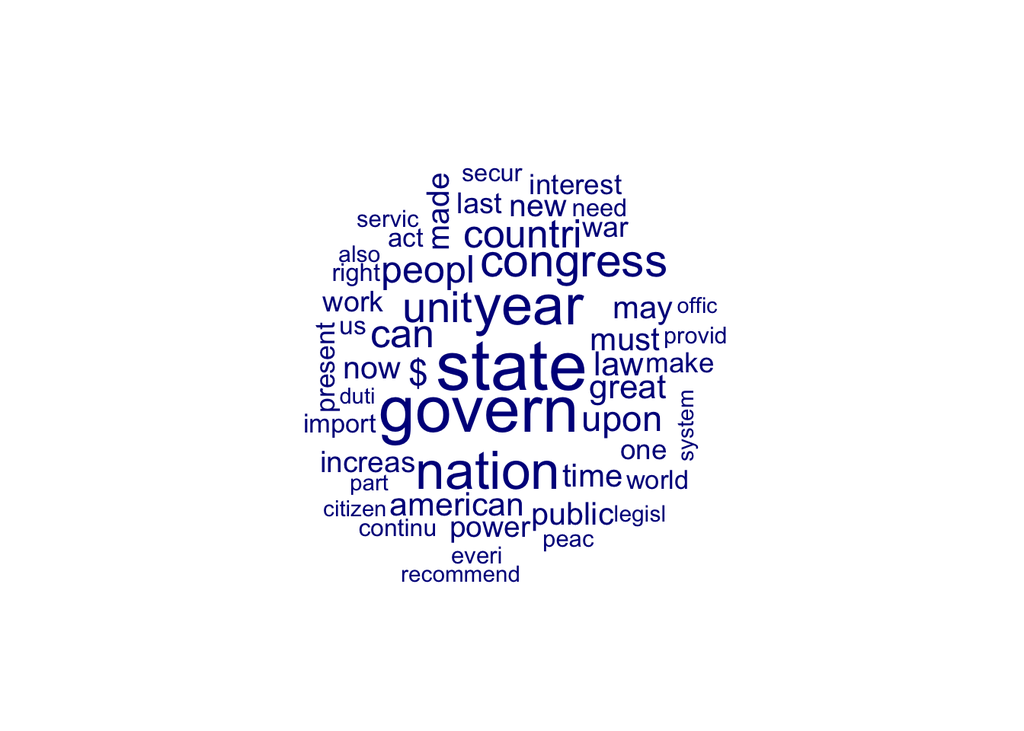

```r
textplot_wordcloud(sotu_dfm, max_words = 50)     # top 50 wörter
```

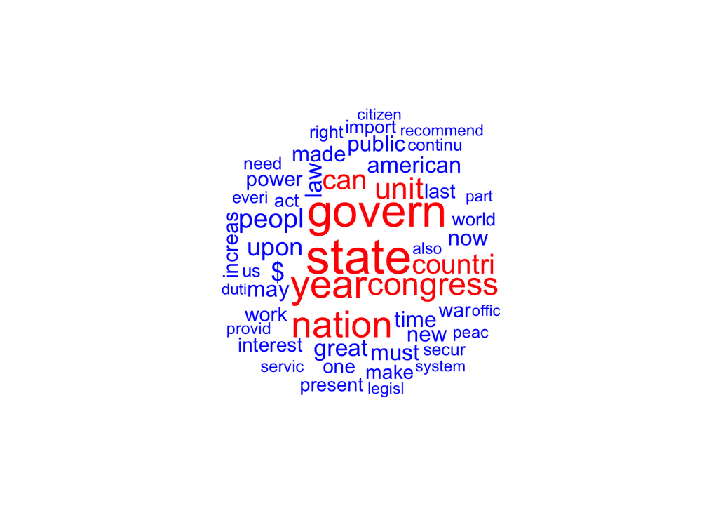

```r
textplot_wordcloud(sotu_dfm, max_words = 50, color = c('blue','red')) # farben verändern
```

```r
textstat_frequency(sotu_dfm, n = 10)             # häufigkeiten
```

```
##     feature frequency rank docfreq group
## 1     state      9234    1    5580   all
## 2    govern      8581    2    5553   all
## 3      year      7250    3    4934   all
## 4    nation      6733    4    4847   all
## 5  congress      5689    5    4494   all
## 6      unit      5223    6    3715   all
## 7       can      4731    7    3628   all
## 8   countri      4664    8    3612   all
## 9     peopl      4477    9    3388   all
## 10     upon      4168   10    3004   all
```

Mit `docvars(dtm)` erhalten wir einen data.frame mit den Dokumentvariablen. Mit `docvars(dtm)$Präsident` erhalten wir den Zeichenvektor mit den Namen der Präsidenten. Mit `docvars(dtm)$Präsident == 'Barack Obama'` suchen wir nach allen Dokumenten, in denen der Präsident Obama war. Um dies zu verdeutlichen, speichern wir den logischen Vektor, der anzeigt, welche Dokumente 'TRUE' sind, als `is_obama`. Diesen verwenden wir dann, um diese Zeilen aus dem DFM auszuwählen.

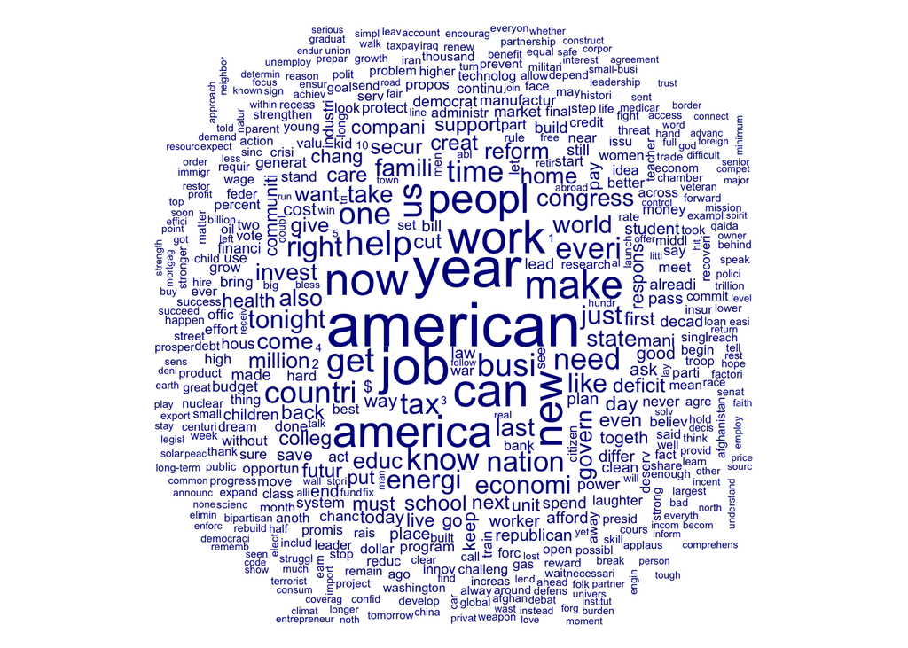

```r
is_obama <-  docvars(sotu_dfm)$President == 'Barack Obama'
obama_dtm <-  sotu_dfm[is_obama,]
textplot_wordcloud(obama_dtm) # diesmal ohne eine max_words einschränkung
```

#### 3.3.2 Korpora vergleichen

Hier verwenden wir (wieder) einen Vergleich, um den `is_obama`-Vektor zu erhalten. Diesen verwenden wir dann in der Funktion `textstat_keyness`, um anzugeben, dass wir die Obama-Dokumente (bei denen `is_obama` TRUE ist) mit allen anderen Dokumenten (bei denen `is_obama` FALSE ist) vergleichen wollen.

```r
is_obama <-  docvars(sotu_dfm)$President == 'Barack Obama'
sotus_obama_all <-  textstat_keyness(sotu_dfm, is_obama)
head(sotus_obama_all, 20)    ## view first 20 results
```

```
##       feature      chi2 p n_target n_reference
## 1         job 1933.3089 0      203         626
## 2         get 1204.4340 0      121         355
## 3         kid  609.4350 0       31          34
## 4      colleg  578.4565 0       57         160
## 5     tonight  496.7241 0       82         400
## 6        know  477.8215 0      108         695
## 7  small-busi  474.9019 0       14           3
## 8     america  439.8990 0      170        1644
## 9      afghan  422.3037 0       17          11
## 10 republican  395.0948 0       41         121
## 11        ceo  358.8193 0        9           0
## 12       cori  358.8193 0        9           0
## 13   american  355.8810 0      245        3385
## 14   laughter  348.2707 0       28          60
## 15    student  336.6490 0       41         144
## 16      clean  336.5539 0       35         103
## 17      innov  334.6970 0       27          58
## 18   trillion  320.6739 0       16          16
## 19       folk  314.4029 0       14          11
## 20      biden  314.1668 0        8           0
```

Unsere Ergebnisse können wir mit der Funktion `textplot_keyness` visualisieren:

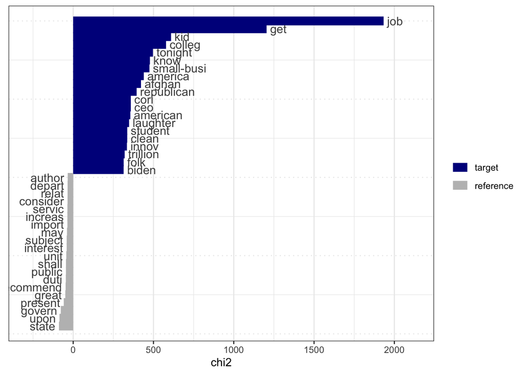

```r
textplot_keyness(sotus_obama_all)
```

#### 3.3.3 Key-word-in-Context

Ein Keyword-in-Context-Listing zeigt ein bestimmtes Keyword im Kontext seiner Verwendung. Generell ist das eine gute Methode einen Korpus kennenzulernen. Da ein DFM nur Worthäufigkeiten kennt, benötigen wir für die `kwic`-Funktion das Korpusobjekt.

```r
sotu_tokens <- tokens(sotu_corpus)
sotus_kwic <- kwic(sotu_tokens, 'freedom', window = 5)
head(sotu_corpus, 10)    ## only view first 10 results
```

```
## Corpus consisting of 10 documents and 4 docvars.
## text1 :
## "I embrace with great satisfaction the opportunity which now ..."
##
## text2 :
## "In resuming your consultations for the general good you can ..."
##
## text3 :
## "Among the many interesting objects which will engage your at..."
##
## text4 :
## "A free people ought not only to be armed, but disciplined; t..."
##
## text5 :
## "The proper establishment of the troops which may be deemed i..."
##
## text6 :
## "There was reason to hope that the pacific measures adopted w..."
##
## [ reached max_ndoc ... 4 more documents ]
```

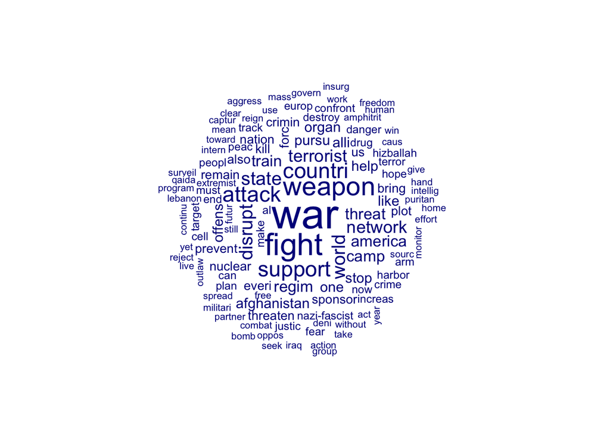

```r
sotus_terror <-  kwic(sotu_tokens, 'terror*')

sotus_terror_corp <-  corpus(sotus_terror)

sotus_terror_tokens <- tokens(sotus_terror_corp, remove_punct=T) %>%
  tokens_remove(pattern = stopwords("en")) %>%
  tokens_tolower() %>%
  tokens_wordstem()

sotus_terror_dtm <-  dfm(sotus_terror_tokens)

textplot_wordcloud(sotus_terror_dtm)
```

Wie würde diese Kette von Befehlen in einer Pipeline aussehen? Probiert es mal aus!

#### 3.3.4 Wörterbücher

Wir können mit `quanteda` ganz einfach eine Wörterbuchsuche/-analyse durchführen. In Sitzung 6 werden wir noch genauer darauf eingehen. Aus diesem Grund werde ich euch im folgenden Beispiel zeigen, wie man bereits bei der Erstellung einer DFM Wörterbuchbegriffe einbaut. Vergesst bitte nicht, dass Wörterbücher nur dann aussagekräftig sind, wenn sie theoriegeleitet erstellt und auf ihre Validität hin überprüft wurden.

```r
sotu_tokens <- tokens(sotu_corpus, remove_punct=T) %>%
  tokens_remove(pattern = stopwords("en")) %>%
  tokens_tolower() # zu Präsentationszwecken ohne Stemming

sotu_dfm <-  dfm(sotu_tokens)
sotu_dfm
```

```
## Document-feature matrix of: 23,469 documents, 31,302 features (99.88% sparse) and 4 docvars.
##        features
## docs    embrace great satisfaction opportunity now presents congratulating
##   text1       1     1            1           1   1        1              1
##   text2       0     0            0           0   0        0              0
##   text3       0     0            0           0   0        0              0
##   text4       0     0            0           0   0        0              0
##   text5       0     0            0           0   0        0              0
##   text6       0     0            0           0   0        0              0
##        features
## docs    present favorable prospects
##   text1       1         1         1
##   text2       1         0         0
##   text3       0         0         0
##   text4       0         0         0
##   text5       0         0         0
##   text6       0         0         0
## [ reached max_ndoc ... 23,463 more documents, reached max_nfeat ... 31,292 more features ]
```

```r
sotus_dict <-  dictionary(list(terrorism = c("terror*", "bomb*","violence"),
                               economy = c("economy", "tax", "job"),
                               military = c("army","navy","milit*","airforce","soldier*"),
                               freedom = c("freedom","liberty", "democra*")))

sotus_dict_dtm <-  dfm_lookup(sotu_dfm, dict = sotus_dict)
sotus_dict_dtm
```

```
## Document-feature matrix of: 23,469 documents, 4 features (94.63% sparse) and 4 docvars.
##        features
## docs    terrorism economy military freedom
##   text1         0       0        0       0
##   text2         0       0        0       0
##   text3         0       0        0       0
##   text4         0       0        1       0
##   text5         0       1        1       0
##   text6         0       0        0       0
## [ reached max_ndoc ... 23,463 more documents ]
```

Auf dieser Grundlage können wir jetzt unsere Analysen durchführen.

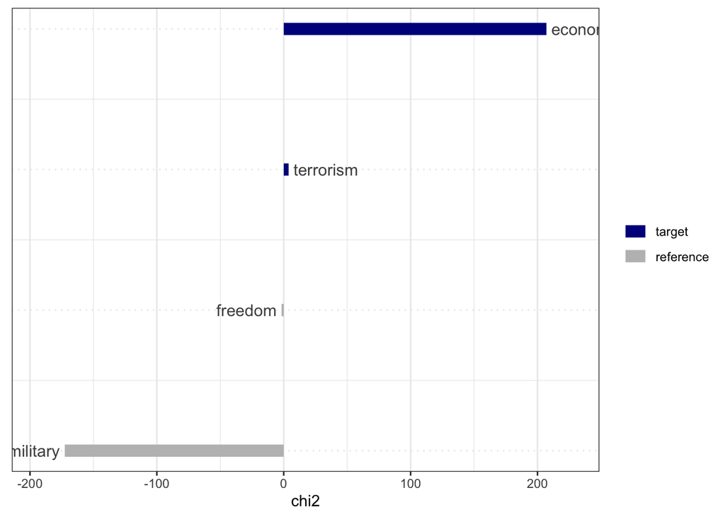

```r
keyness_obama <-  textstat_keyness(sotus_dict_dtm, docvars(sotus_dict_dtm)$President == "Barack Obama")

textplot_keyness(keyness_obama)
```

Wie ihr unschwer erkennen könnt: dieses Wörterbuch ist nicht sehr aussagekräftig. Aber das ist nicht weiter schlimm, hier geht es ja lediglich um den Zweck der Präsentation.

Wir können die DFM auch in einen Datensatz konvertieren, und erhalten dann die Anzahl der einzelnen Konzepte pro Dokument (die man dann z. B. mit Umfragedaten abgleichen könnte).

```r
sotus_dict_df <-  convert(sotus_dict_dtm, to="data.frame")
head(sotus_dict_df)
```

```
##   doc_id terrorism economy military freedom
## 1  text1         0       0        0       0
## 2  text2         0       0        0       0
## 3  text3         0       0        0       0
## 4  text4         0       0        1       0
## 5  text5         0       1        1       0
## 6  text6         0       0        0       0
```

#### 3.3.5 Die Gültigkeit von Wörterbüchern testen

Ein gutes Wörterbuch bedeutet, dass alle Dokumente, die mit dem Wörterbuch übereinstimmen, tatsächlich von dem gewünschten Konzept handeln oder dieses enthalten.

Um das zu überprüfen, können wir eine Stichprobe von Dokumenten manuell kodieren und die Ergebnisse mit den Treffern im Wörterbuch vergleichen. Dazu mehr in Sitzung 6!

Wir können aber auch die Keyword-in-Context-Funktion auf ein Wörterbuch anwenden, um so schnell eine Reihe von Übereinstimmungen zu prüfen und zu sehen, ob sie sinnvoll sind:

```r
kwic(sotu_corpus, sotus_dict$terrorism)
```

```
## Keyword-in-context with 501 matches.
##    [text129, 109]               produced symptoms of riot and |  violence   |
##     [text220, 31]             our citizens from injustice and |  violence   |
##    [text223, 102]                     , ambition, avarice and |  violence   |
##     [text294, 73]                     our pacific policy, the |  violence   |
##      [text408, 7]              from these unpleasant views of |  violence   |
##     [text601, 62]               by adverse weather of unusual |  violence   |
##     [text607, 36]         that they would experience whatever |  violence   |
##      [text631, 3]                              This increased |  violence   |
##     [text735, 80]                , will henceforth lose their |   terror    |
##   [text1328, 108]              of honest commerce seized with |  violence   |
##   [text1433, 236]              has disarmed revolution of its |   terrors   |
##    [text1446, 31]                         , it would be doing |  violence   |
##    [text1579, 46]                 any recurrence of a similar |  violence   |
##    [text1614, 86]                     which it has spread its |   terrors   |
##    [text1791, 95]                         , she would but add |  violence   |
##    [text1803, 73]                   the land with anarchy and |  violence   |
##    [text1810, 55]                  has wantonly produced, the |  violence   |
##    [text1947, 11]                 for losses sustained at the | bombardment |
##   [text2097, 137]           be readily executed without doing |  violence   |
##   [text2136, 265]                   the commission of acts of |  violence   |
##    [text2159, 73]                      , and all but produced |  violence   |
##   [text2174, 363]         for their security against external |  violence   |
##   [text2288, 152]             of adverse circumstances or the |  violence   |
##   [text2394, 119]           against invasion from without and |  violence   |
##   [text2448, 106]                   commission of any acts of |  violence   |
##    [text2820, 36]            sure safeguard against force and |  violence   |
##   [text3057, 184]            military despotism or of popular |  violence   |
##    [text3087, 62]                    are a source of constant |   terror    |
##   [text3403, 198]                   , effectually, to prevent |  violence   |
##    [text3404, 90]               but treated with rudeness and |  violence   |
##   [text3406, 141]                   a time specified he would |   bombard   |
##   [text3406, 301]         to protest against the contemplated | bombardment |
##    [text3407, 26]                            for" a resort to |  violence   |
##    [text3505, 63]         against either invasion or domestic |  violence   |
##    [text3527, 16]                      . It was attacked with |  violence   |
##   [text3527, 176]             reactionary effect of their own |  violence   |
##   [text3542, 133]                 be only aggravated by their |  violence   |
##   [text3561, 135]                      gravity of the acts of |  violence   |
##   [text3561, 165]          been seemingly filled with extreme |  violence   |
```

[output cut: 949 more lines]

```
##  . But this time is
##  . They deserve a vote
##  , they deserve a simple
##  in this country. In
##  do not launch attacks against
##  not just through intelligence and
##  steals from us each day
##  networks. Here at home
##  prefer from us: large-scale
##  networks through more targeted efforts
##  , and fear. As
##  . And with our allies
##  organizations like Hizballah, which
##  . If John F.
##  in Afghanistan. His comrades
```